# 8_MLPS_R_tree_methods

Runshan Fu (TA - Heinz CMU PhD)

2/27/2017

## Lecture 8: Tree-based Methods

Key specific tasks we covered in this lecture:

- estimating a decision tree
- predict both class probabilities and class predictions
- pre-pruning options
- chi-sq hypothesis tests

Commonly used packages for decision tree includes `tree` and `rpart`. ISLR (page 323 - 331) have detailed examples for `tree`, and we show basic usage of `rpart` here, using the same dataset.

```r
# Load dataset
library(ISLR)
attach(Carseats)
# create a varialbe, called 'High', which takes on a value of 'Yes' if the 'Sales' varialbe exceeds 8, and 'No' otherwise.
High <- ifelse(Sales<=8, "No", "Yes")
# merge 'High' with the rest of the data
Carseats <- data.frame(Carseats, High)
# split the data into training set and test set
set.seed(2)
train <- sample(1:nrow(Carseats), 200)
carseats.train <- Carseats[train,]
carseats.test <- Carseats[-train,]
```

Estimate a decision tree using the training set:

```r
library(rpart)
tree.carseats <- rpart(High ~ .-Sales, data = Carseats, subset = train)
summary(tree.carseats)
```

```
## Call:
## rpart(formula = High ~ . - Sales, data = Carseats, subset = train)
##   n= 200
##
##           CP nsplit rel error xerror       xstd
## 1 0.28750000      0    1.0000  1.000 0.08660254
## 2 0.10000000      1    0.7125  0.800 0.08246211
## 3 0.06250000      2    0.6125  0.800 0.08246211
## 4 0.05000000      3    0.5500  0.775 0.08175803
## 5 0.02083333      4    0.5000  0.650 0.07754031
## 6 0.01000000      7    0.4375  0.625 0.07654655
##
## Variable importance
##       Price   ShelveLoc   CompPrice Advertising         Age  Population
##          33          27          13          11           7           3
##   Education      Income
##           3           3
##
## Node number 1: 200 observations,    complexity param=0.2875
##   predicted class=No   expected loss=0.4  P(node) =1
##     class counts:   120    80
##    probabilities: 0.600 0.400
##   left son=2 (153 obs) right son=3 (47 obs)
##   Primary splits:
##       ShelveLoc   splits as  LRL,       improve=14.598250, (0 missing)
##       Price       < 89.5  to the right, improve=11.564780, (0 missing)
##       Advertising < 13.5  to the left,  improve= 7.976744, (0 missing)
##       Age         < 38.5  to the right, improve= 4.708107, (0 missing)
##       Income      < 61.5  to the left,  improve= 2.618926, (0 missing)
##   Surrogate splits:
##       Price < 163.5 to the left,  agree=0.77, adj=0.021, (0 split)
##
## Node number 2: 153 observations,    complexity param=0.1
##   predicted class=No   expected loss=0.2941176  P(node) =0.765
##     class counts:   108    45
##    probabilities: 0.706 0.294
##   left son=4 (139 obs) right son=5 (14 obs)
##   Primary splits:
##       Price       < 86.5  to the right, improve=7.448220, (0 missing)
##       Advertising < 13.5  to the left,  improve=5.827908, (0 missing)
```

[output cut: 108 more lines]

```
##   Surrogate splits:
##       Income     < 33    to the right, agree=0.783, adj=0.286, (0 split)
##       Price      < 102.5 to the left,  agree=0.783, adj=0.286, (0 split)
##       Education  < 16.5  to the left,  agree=0.783, adj=0.286, (0 split)
##       Population < 127.5 to the right, agree=0.739, adj=0.143, (0 split)
##
## Node number 70: 16 observations
##   predicted class=No   expected loss=0.375  P(node) =0.08
##     class counts:    10     6
##    probabilities: 0.625 0.375
##
## Node number 71: 7 observations
##   predicted class=Yes  expected loss=0.1428571  P(node) =0.035
##     class counts:     1     6
##    probabilities: 0.143 0.857
```

Please note that rpart take several optional paramters to further configure the tree. See the documents(https://cran.r-project.org/web/packages/rpart/rpart.pdf) for more details.

Visualize the tree:

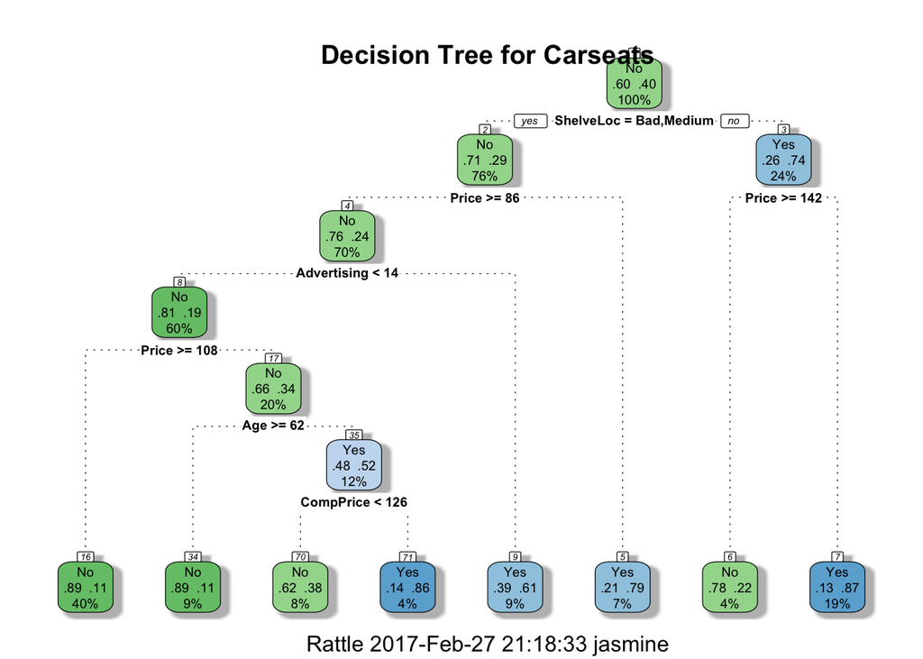

```r
library(rattle)
fancyRpartPlot(tree.carseats, main = "Decision Tree for Carseats")
```

Predict class probabilities for test set:

```r
pred.prob <- predict(tree.carseats, newdata = carseats.test, type = "prob")
# sample precited probability
pred.prob[0:10,]
```

```
##           No       Yes
## 1  0.8875000 0.1125000
## 2  0.1315789 0.8684211
## 5  0.8875000 0.1125000
## 9  0.8875000 0.1125000
## 10 0.8875000 0.1125000
## 12 0.1315789 0.8684211
## 13 0.8875000 0.1125000
## 15 0.1315789 0.8684211
## 16 0.8875000 0.1125000
## 18 0.1315789 0.8684211
```

Predict class for test set and compare with the true lables

```r
pred.class <- predict(tree.carseats, newdata = carseats.test, type = "class")
# the confusion matrix
table(pred.class, carseats.test$High)
```

```
##
## pred.class No Yes
##        No  90  20
##        Yes 26  64
```